# Using gridlayout with .Rmds

```r
library(gridlayout)
```

By placing the function `use_gridlayout_rmd` in the `setup` chunk of an Rmd you can define a gridlayout table using the a code chunk with the “language” set to `gridlayout`. Any markdown style table (see `md_to_gridlayout()`) will be used to setup a grid-layout for your page. Just make sure your sections are given headers corresponding to the respective grid elements (either using their name or by using the `#My header text {#custom_id}` syntax after the header.)

The following shows how you can customize the appearance of the elements of your layout using “card styles” and custom css.

# Starting point

All the screenshots below will assume an `.Rmd` that looks like this

````
## Main


```gridlayout
|      |        |         |
|------|--------|---------|
|2rem  |200px   |1fr      |
|150px |header  |header   |
|1fr   |sidebar |main     |
|120px |footer  |footer   |
```


## Sidebar {.grid_panel}

Here is some content for the sidebar

## Footer

Anything you want could go in the footer.
````

## Default settings

The default settings will give every element a card-like styling.

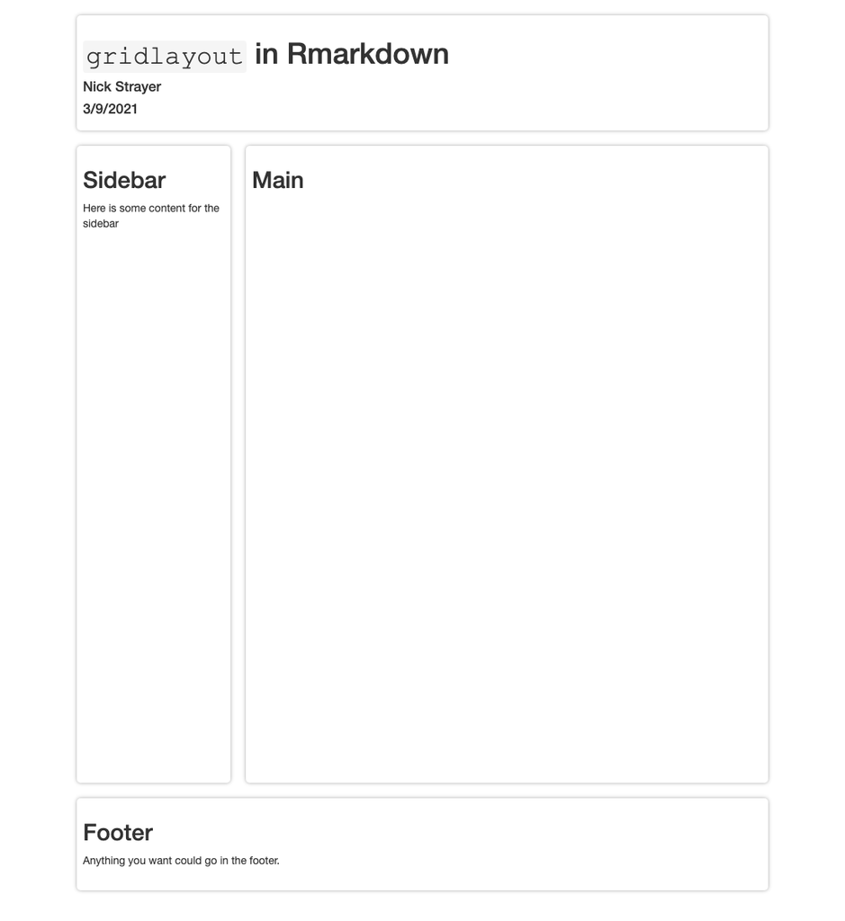

```r
use_gridlayout_rmd()
```

## Targeting specific elements for card styling

By adjusting the argument `is_card_styled` you can customize what gets these card styles. For instance, here we give the card styles to elements with the `grid_panel` class.

Note that in the `.Rmd` above that only the sidebar had the class of `grid_panel` added to it using the syntax `{.grid_panel}`.

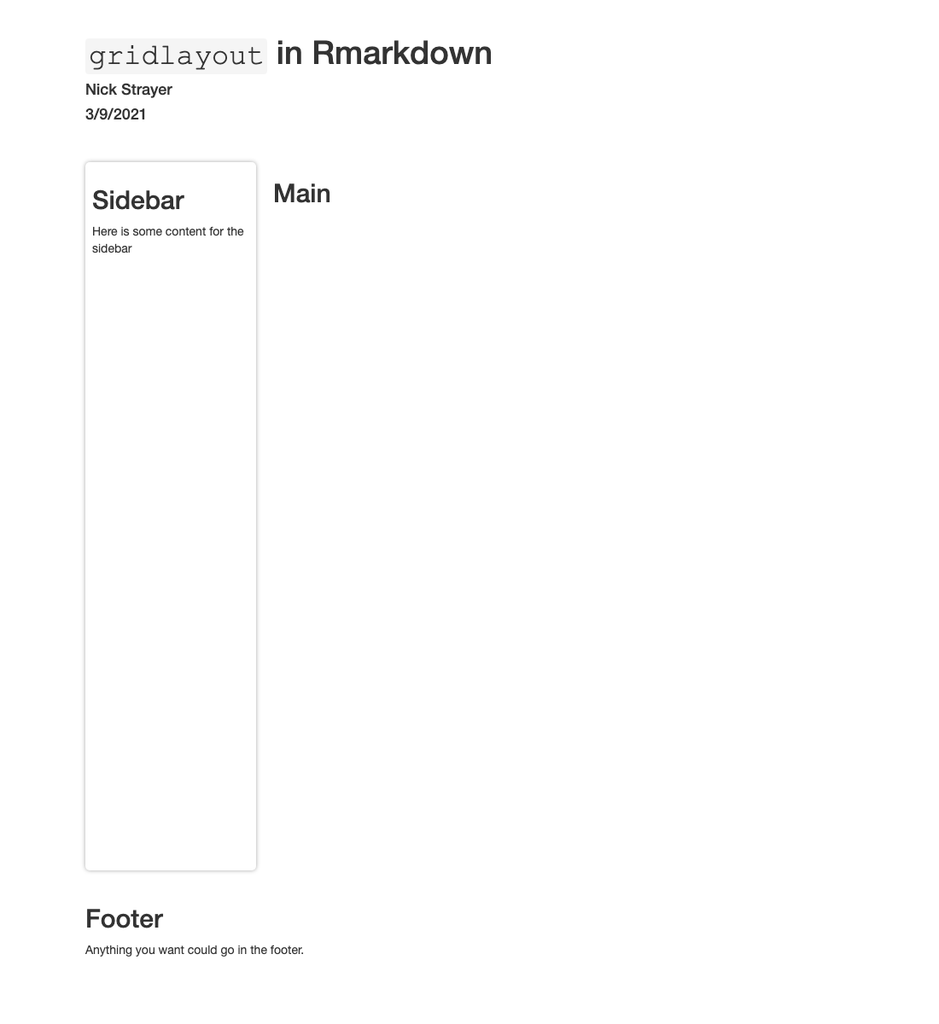

```r
use_gridlayout_rmd(is_card_styled = "grid_panel")
```

## Adding extra styles to elements

The elements can be additionally styled with any arbitrary styles you want via the `element_styles` argument. Here we give every element the background of “honeydew”.

```r
use_gridlayout_rmd(
  is_card_styled = "grid_panel",
  element_styles = c("background" = "honeydew")
)
```

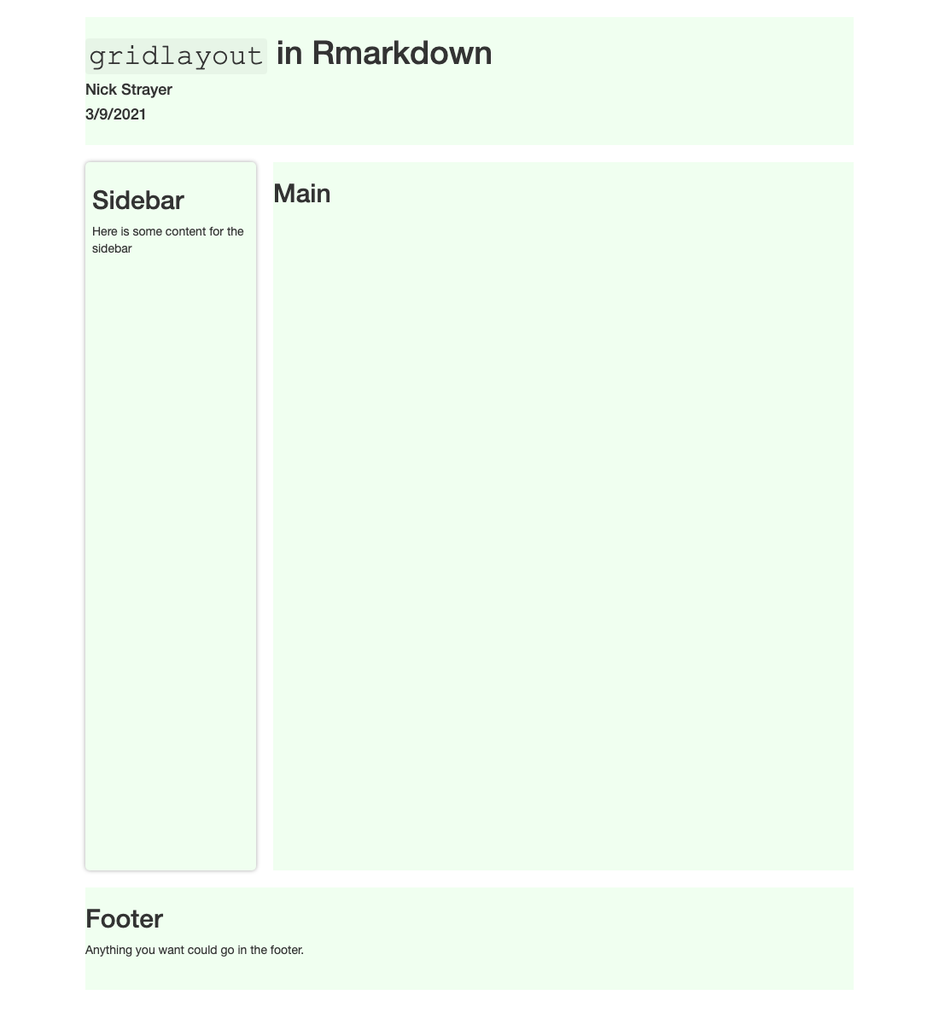